# Conclusion

```python
import pandas
```

```python
data_models = [[2, 16, 'binary_crossentropy', 'relu'], [1, 16, 'binary_crossentropy', 'relu'], [3, 16, 'binary_crossentropy', 'relu'], [2, 32, 'binary_crossentropy', 'relu'], [2, 64, 'binary_crossentropy', 'relu'], [2, 16, 'mse', 'relu'], [2, 16, 'binary_crossentropy', 'tanh'], [1, 16, 'mse', 'tanh'], [1, 16, 'binary_crossentropy', 'tanh']]
```

```python
df = pandas.DataFrame(data_models, index=[1,2,3,4,5,6,7,8,9], columns=['# of Hidden Layers', '# of Hidden Units', 'Loss Function', 'Activation'])
print(df)
```

```
   # of Hidden Layers  # of Hidden Units        Loss Function Activation
1                   2                 16  binary_crossentropy       relu
2                   1                 16  binary_crossentropy       relu
3                   3                 16  binary_crossentropy       relu
4                   2                 32  binary_crossentropy       relu
5                   2                 64  binary_crossentropy       relu
6                   2                 16                  mse       relu
7                   2                 16  binary_crossentropy       tanh
8                   1                 16                  mse       tanh
9                   1                 16  binary_crossentropy       tanh
```

```python
data_avgs = [[88.34, 87.69], [88.88, 88.26], [88.52, 87.94], [88.09, 87.31], [87.13, 86.06], [88.33, 87.88], [88.48, 87.78], [88.67, 88.31], [88.86, 88.30]]
```

```python
df2 = pandas.DataFrame(data_avgs, index=[1,2,3,4,5,6,7,8,9], columns=['Validation Accuracy', 'Test Accuracy'])
print(df2)
```

```
   Validation Accuracy  Test Accuracy
1                88.34          87.69
2                88.88          88.26
3                88.52          87.94
4                88.09          87.31
5                87.13          86.06
6                88.33          87.88
7                88.48          87.78
8                88.67          88.31
9                88.86          88.30
```

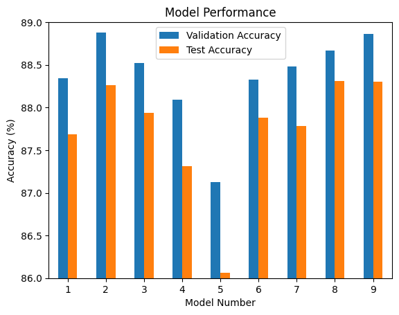

```python
plot = df2.plot.bar(ylim=(86.0, 89.0), rot= 0, title="Model Performance")
plot.set_xlabel("Model Number")
plot.set_ylabel("Accuracy (%)")
plot
```

## In conclusion, all nine model validation and test accuracies fell within a relatively narrow range between roughy 86.0% and 89.0%. Additionally, all models were built using epoch = 4 after analysis determined this was the best epoch value. Increasing the number of hidden units negatively impacted model performance, as displayed by the lowest validation and test accuracies in models 4 and 5. Adjusting the loss function had minimal impact on model performance (model 6), while utilizing the tanh activation marginally improved model performance (model 7). Lastly, using only one hidden layer had the largest impact on improving model performance (models 2, 8, 9).

## Model 9 (1 hidden layer, 16 hidden units, binary_crossentropy loss function, tanh activation) overall had the best performance with 88.86% validation accuracy and 88.30% test accuracy. Model 2 (1 hidden layer, 16 hidden units, binary_crossentropy loss function, relu activation) was a very close second with 88.88% validation accuracy and 88.26% test accuracy.

```python
!jupyter nbconvert --execute -- to html "/content/drive/MyDrive/Colab Notebooks/BA 64061 Assignment 1 Conclusion Madeline Witzeman"
```

[output not shown]